# Part A

## Part A

```r
summary(probit_w)
```

```
##
## Call:
## glm(formula = canceled ~ temp + wind_speed + precip + pressure +
##     visib, family = binomial(link = "probit"), data = flights_weather)
##
## Deviance Residuals:
##     Min       1Q   Median       3Q      Max
## -0.1118  -0.0610  -0.0458  -0.0350   4.1635
##
## Coefficients:
##               Estimate Std. Error z value Pr(>|z|)
## (Intercept)  8.0371493  2.4394759   3.295 0.000986 ***
## temp         0.0091758  0.0009432   9.728  < 2e-16 ***
## wind_speed   0.0003826  0.0006380   0.600 0.548691
## precip      -0.8271819  1.0166215  -0.814 0.415841
## pressure    -0.0110009  0.0023941  -4.595 4.33e-06 ***
## visib       -0.0449892  0.0088125  -5.105 3.30e-07 ***
## ---
## Signif. codes:  0 '***' 0.001 '**' 0.01 '*' 0.05 '.' 0.1 ' ' 1
##
## (Dispersion parameter for binomial family taken to be 1)
##
##     Null deviance: 5833.7  on 291199  degrees of freedom
## Residual deviance: 5658.2  on 291194  degrees of freedom
##   (36375 observations deleted due to missingness)
## AIC: 5670.2
##
## Number of Fisher Scoring iterations: 9
```

This probit regression shows that for canceled flights, temperature, pressure, and visibility are the most significant factors.

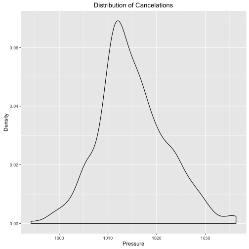

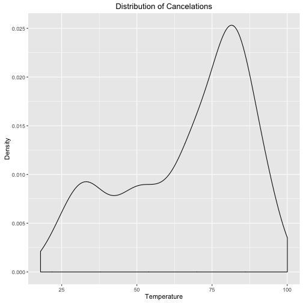

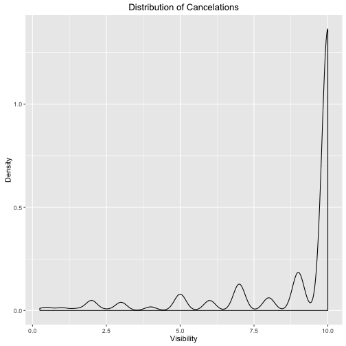

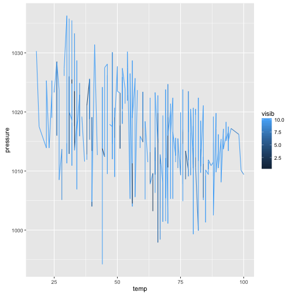

The graph shows the relationship between temperature and pressure of canceled flights and it also shows the varing visability.

```r
summary(probit_w_delayed)
```

```
##
## Call:
## glm(formula = delayed ~ temp + wind_speed + precip + pressure +
##     visib, family = binomial(link = "probit"), data = flights_weather)
##
## Deviance Residuals:
##     Min       1Q   Median       3Q      Max
## -2.6785  -0.9829  -0.8806   1.3238   1.7137
##
## Coefficients:
##               Estimate Std. Error z value Pr(>|z|)
## (Intercept)  8.8429923  0.3446857  25.655   <2e-16 ***
## temp         0.0056011  0.0001326  42.237   <2e-16 ***
## wind_speed   0.0021804  0.0001513  14.408   <2e-16 ***
## precip       1.4605885  0.1713782   8.523   <2e-16 ***
## pressure    -0.0089520  0.0003378 -26.502   <2e-16 ***
## visib       -0.0404988  0.0016653 -24.320   <2e-16 ***
## ---
## Signif. codes:  0 '***' 0.001 '**' 0.01 '*' 0.05 '.' 0.1 ' ' 1
##
## (Dispersion parameter for binomial family taken to be 1)
##
##     Null deviance: 385486  on 291199  degrees of freedom
## Residual deviance: 380984  on 291194  degrees of freedom
##   (36375 observations deleted due to missingness)
## AIC: 380996
##
## Number of Fisher Scoring iterations: 25
```

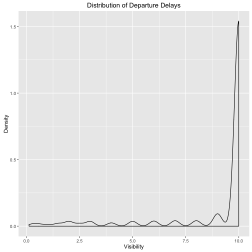

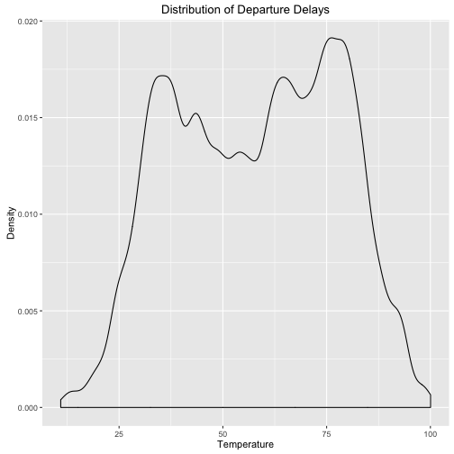

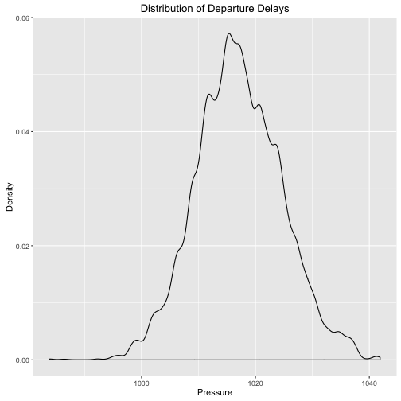

The graphs here show visibility, temperature, and pressure again but for delayed flights. Visibility looks almost the same as before. Temperature has become less skewed and centered around 60 degrees. Pressure is normal and is centered around the same area as cancelations.

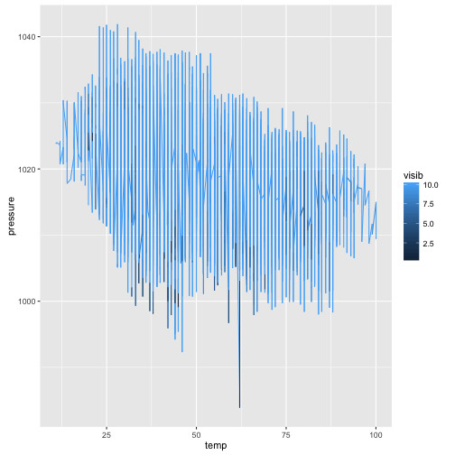

The graph shows the relationship between temperature and pressure of delayed flights and it also shows the varing visability.

## Part B

```r
summary(probit_time)
```

```
##
## Call:
## glm(formula = canceled ~ day + month + hour, family = binomial(link = "probit"),
##     data = flights_weather)
##
## Deviance Residuals:
##     Min       1Q   Median       3Q      Max
## -0.1215  -0.0603  -0.0470  -0.0367   4.1678
##
## Coefficients:
##              Estimate Std. Error z value Pr(>|z|)
## (Intercept) -3.528930   0.089921 -39.245  < 2e-16 ***
## day         -0.003001   0.001670  -1.797  0.07237 .
## month2       0.242120   0.092148   2.628  0.00860 **
## month3       0.185785   0.091947   2.021  0.04333 *
## month4       0.287044   0.088044   3.260  0.00111 **
## month5       0.254188   0.089035   2.855  0.00430 **
## month6       0.421371   0.084258   5.001 5.70e-07 ***
## month7       0.568019   0.080969   7.015 2.30e-12 ***
## month8       0.064646   0.097883   0.660  0.50897
## month9       0.370486   0.085830   4.317 1.59e-05 ***
## month10     -0.099005   0.110908  -0.893  0.37203
## month11      0.082302   0.098254   0.838  0.40223
## month12      0.240254   0.090453   2.656  0.00790 **
## hour         0.022793   0.003047   7.481 7.36e-14 ***
## ---
## Signif. codes:  0 '***' 0.001 '**' 0.01 '*' 0.05 '.' 0.1 ' ' 1
##
## (Dispersion parameter for binomial family taken to be 1)
##
##     Null deviance: 6935.9  on 327574  degrees of freedom
## Residual deviance: 6714.8  on 327561  degrees of freedom
## AIC: 6742.8
##
## Number of Fisher Scoring iterations: 10
```

This table shows that hour and certain months are significant for canceled flights.

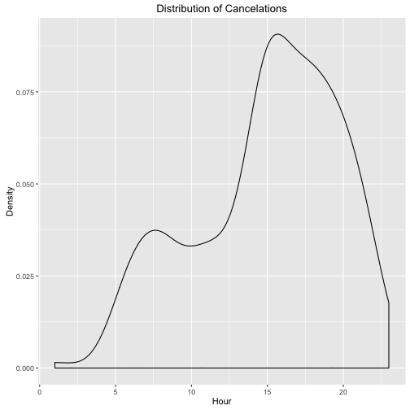

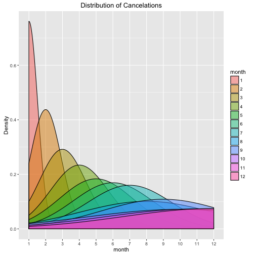

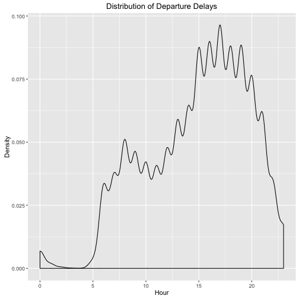

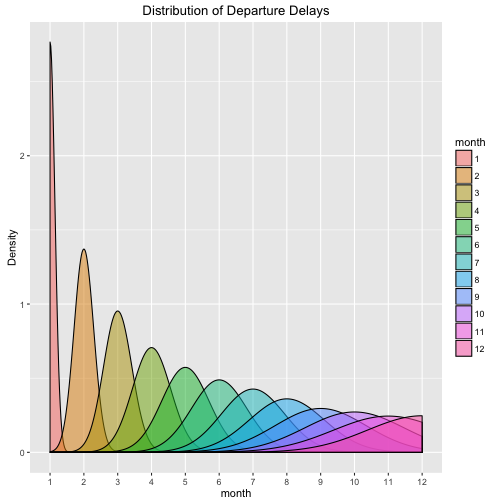

## Part D

```r
summary(probit_plane)
```

```
##
## Call:
## glm(formula = canceled ~ type + manufacturer + engines + seats +
##     engine, family = binomial(link = "probit"), data = flights_planes)
##
## Deviance Residuals:
##     Min       1Q   Median       3Q      Max
## -0.4590  -0.2414  -0.1182  -0.1028   3.4924
##
## Coefficients: (2 not defined because of singularities)
##                                             Estimate Std. Error z value
## (Intercept)                                2.080e+08  3.539e+09   0.059
## typeFixed wing single engine               9.357e-01  3.974e-01   2.355
## typeRotorcraft                            -2.080e+08  3.539e+09  -0.059
## manufacturerAIRBUS                        -2.080e+08  3.539e+09  -0.059
## manufacturerAIRBUS INDUSTRIE              -2.080e+08  3.539e+09  -0.059
## manufacturerAMERICAN AIRCRAFT INC         -2.080e+08  3.539e+09  -0.059
## manufacturerAVIAT AIRCRAFT INC            -2.080e+08  3.539e+09  -0.059
## manufacturerAVIONS MARCEL DASSAULT        -2.080e+08  3.539e+09  -0.059
## manufacturerBARKER JACK L                 -2.080e+08  3.539e+09  -0.059
## manufacturerBEECH                         -2.080e+08  3.539e+09  -0.059
## manufacturerBELL                          -5.369e-02  5.976e-01  -0.090
## manufacturerBOEING                        -2.080e+08  3.539e+09  -0.059
## manufacturerBOMBARDIER INC                -2.080e+08  3.539e+09  -0.059
## manufacturerCANADAIR                      -2.080e+08  3.539e+09  -0.059
## manufacturerCANADAIR LTD                  -2.080e+08  3.539e+09  -0.059
## manufacturerCESSNA                        -2.080e+08  3.539e+09  -0.059
## manufacturerCIRRUS DESIGN CORP            -2.080e+08  3.539e+09  -0.059
## manufacturerDEHAVILLAND                   -2.080e+08  3.539e+09  -0.059
## manufacturerDOUGLAS                       -2.080e+08  3.539e+09  -0.059
## manufacturerEMBRAER                       -2.080e+08  3.539e+09  -0.059
## manufacturerFRIEDEMANN JON                -2.080e+08  3.539e+09  -0.059
## manufacturerGULFSTREAM AEROSPACE          -2.080e+08  3.539e+09  -0.059
## manufacturerHURLEY JAMES LARRY            -2.080e+08  3.539e+09  -0.059
## manufacturerJOHN G HESS                   -2.080e+08  3.539e+09  -0.059
## manufacturerKILDALL GARY                  -2.080e+08  3.539e+09  -0.059
## manufacturerLAMBERT RICHARD               -2.080e+08  3.539e+09  -0.059
## manufacturerLEARJET INC                   -2.080e+08  3.539e+09  -0.059
## manufacturerLEBLANC GLENN T               -2.080e+08  3.539e+09  -0.059
## manufacturerMARZ BARRY                    -2.080e+08  3.539e+09  -0.059
```

[output cut: 55 more lines]

```
## engineReciprocating                         0.2855
## engineTurbo-fan                             0.3600
## engineTurbo-jet                             0.6013
## engineTurbo-prop                                NA
## engineTurbo-shaft                               NA
## ---
## Signif. codes:  0 '***' 0.001 '**' 0.01 '*' 0.05 '.' 0.1 ' ' 1
##
## (Dispersion parameter for binomial family taken to be 1)
##
##     Null deviance: 46658  on 284169  degrees of freedom
## Residual deviance: 43140  on 284128  degrees of freedom
## AIC: 43224
##
## Number of Fisher Scoring iterations: 18
```

Certain manufacturers are significant and seats are significant once I removed model type. I removed model type from this regression because the probit was taking a very long time to run. However, this explains why seats is significant

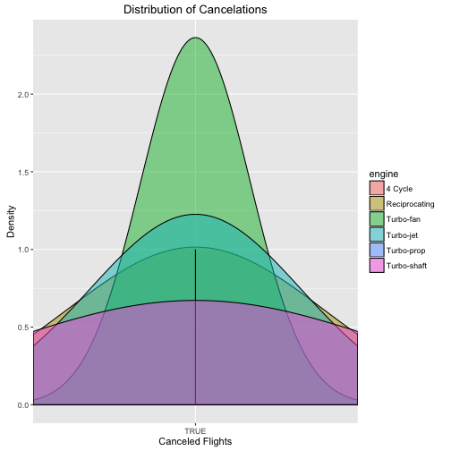

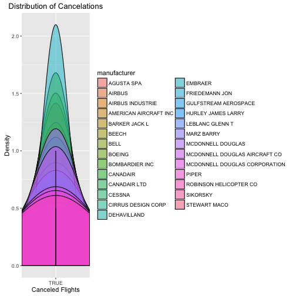

The first graph shows the distribution of cancelled flights for engine type. Turbo-fan engines tend to be the most type of engine type that has cancelled flights. The second graph shows the distribution of manufacturers. Embraer shows to have the most cancelled flights.

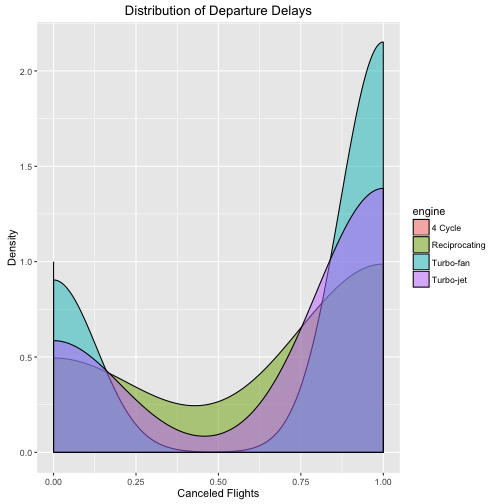

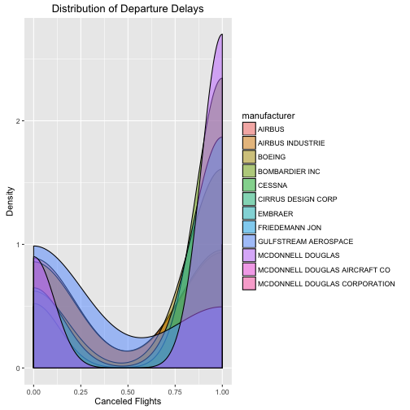

These graphs show the distributions of delayed flights for engines and for manufacturer. Turbo-fan engines have the most delays and the manufacturer McDonnell Douglas has the most delays